# Homework 2: Reference Plots

These are example results for Homework 2. Different themes and colors are acceptable when they follow the task requirements. Plotting code is hidden.

## {!} Important notes for every plot you create:

- Name the axis and legends
- Use some theme (e.g. `theme_classic()`) if ggplot is used. *Not necessarily the same one for all plots.*

# Palmer Penguins

#### 0. Read file `data/penguins.csv`

- *Don’t forget to use all necessary parameters*
- Look at the data (summary? structure? something else you want)

The `penguins` dataset contains data collected on three penguin species (Adelie, Chinstrap, and Gentoo) from three islands (Torgersen, Biscoe, and Dream) in the Palmer Archipelago, Antarctica.

It includes measurements like:

- `bill_length_mm` and `bill_depth_mm` - dimensions of the penguin’s bill.
- `flipper_length_mm` - length of the penguin’s flippers.
- `body_mass_g` - weight of the penguins in grams.
- `island` - the island where the penguins were observed.
- `sex`: the gender of the penguin.

Some rows may contain missing values (e.g., in `sex` column).

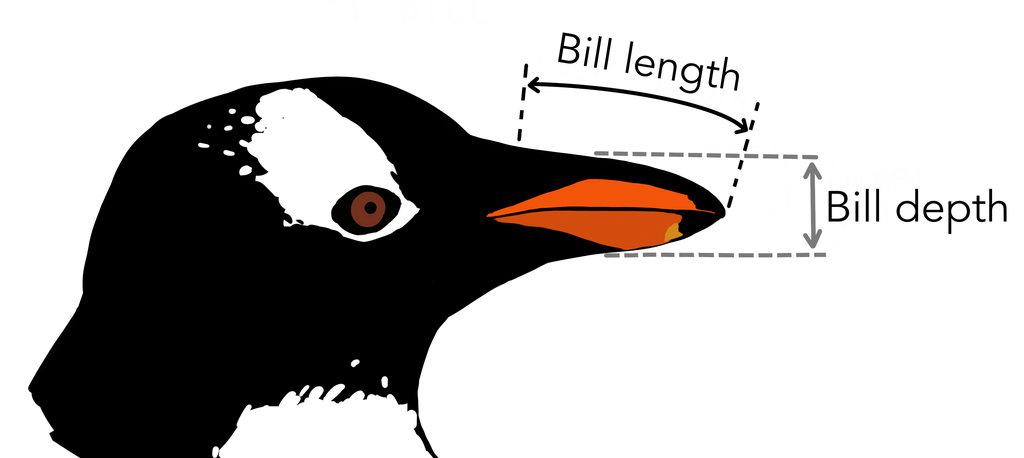

#### 1. Remove rows with a missing value in any of the four measurement columns: `bill_length_mm`, `bill_depth_mm`, `flipper_length_mm`, or `body_mass_g`.

- Remember `complete.cases()` and remember the ways we filtered datasets
- Ensure, that dataset was filtered!

#### 2. Create bar plot to show the number of observations (rows) for each `species` and delete legend (if `ggplot` used).

- Label the axes and legends
- Colors (`fill`) should also be different for each species
- **This task can be solved using either basic R or `ggplot`**
- *Tip:* you may use `table()` or just `geom_bar()`
- **Is the legend needed here?** *(if ggplot used)*

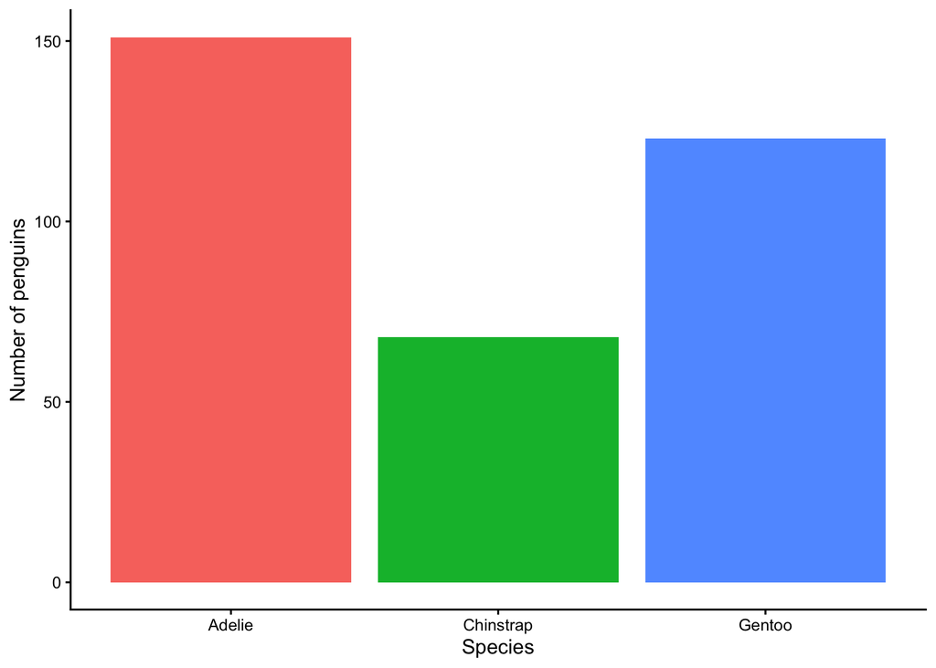

#### 3. Create stacked barplot scaled from 0 to 1 to show the proportion of `species` on each `island`.

- `fill` should represent `species`.
- Don’t forget change `position` parameter

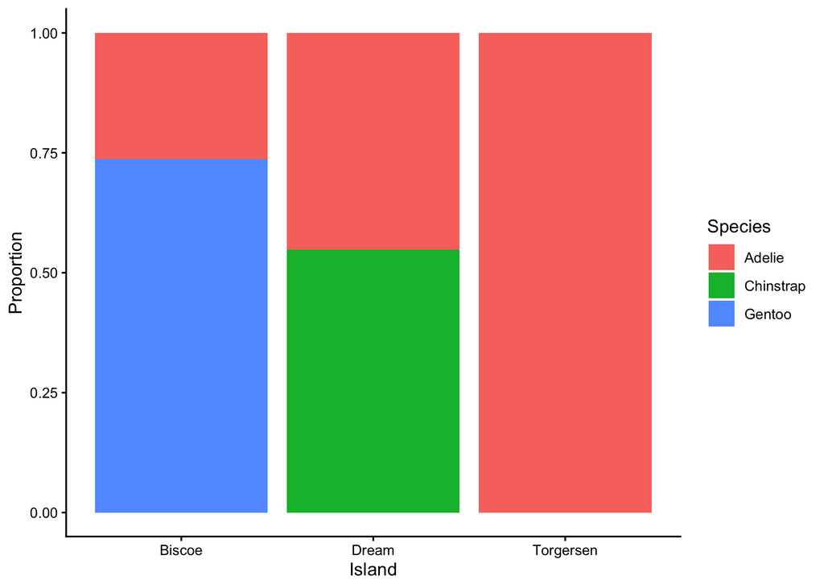

#### 4. Create a histogram for the `flipper_length_mm` and draw the vertical line to show mean value

- Set the number of breaks to 10
- The histogram fill should be `"lightblue"` and border (color) should be `"black"`
- Vertical line color = `'red'`, width = `1.2`
- **This task can be solved using either basic R or `ggplot`**

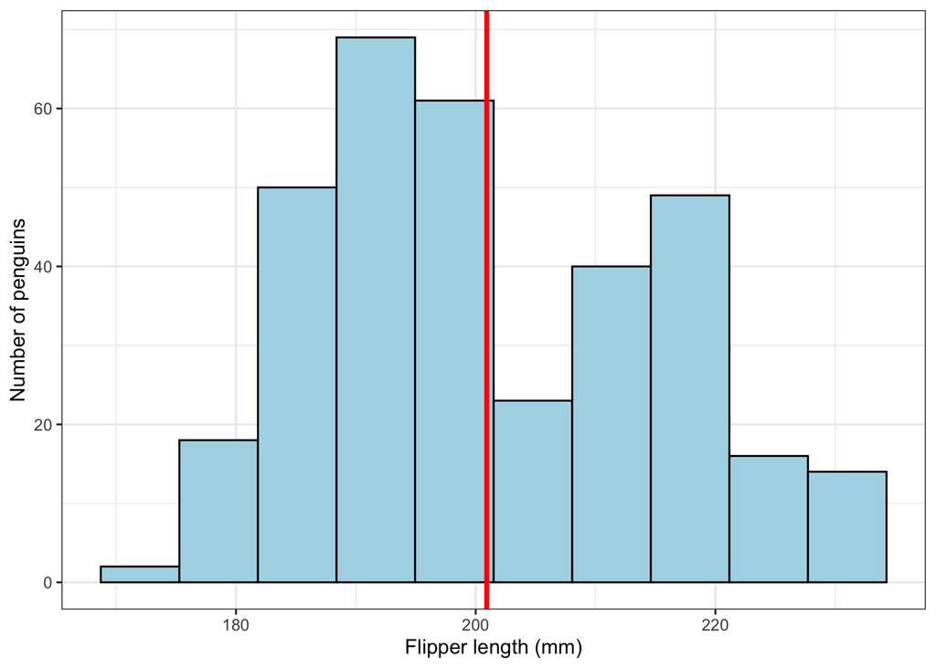

#### 5. Create a density plot for the `body_mass_g` variable. Fill the density regions based on `species`.

- Label the axes (y-axis is `Density`)
- `fill` should be different for each species
- Density plot should have `alpha=0.5`

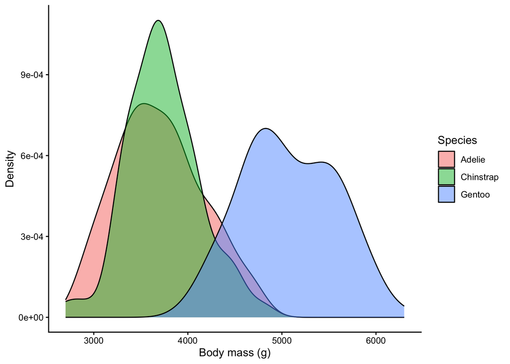

#### 6. Use ggplot to create boxplots grouped by `sex` to compare `bill_length_mm`. Save the plot in a variable using `<-` and display it.

- **Filter out observations without known `sex`** **(!)**
- Colors (`fill`) should also be different for each `sex`
- **When you save the plot in a variable, chart is not displayed. Don’t forget to show the plot by writing the variable name on a new line!**

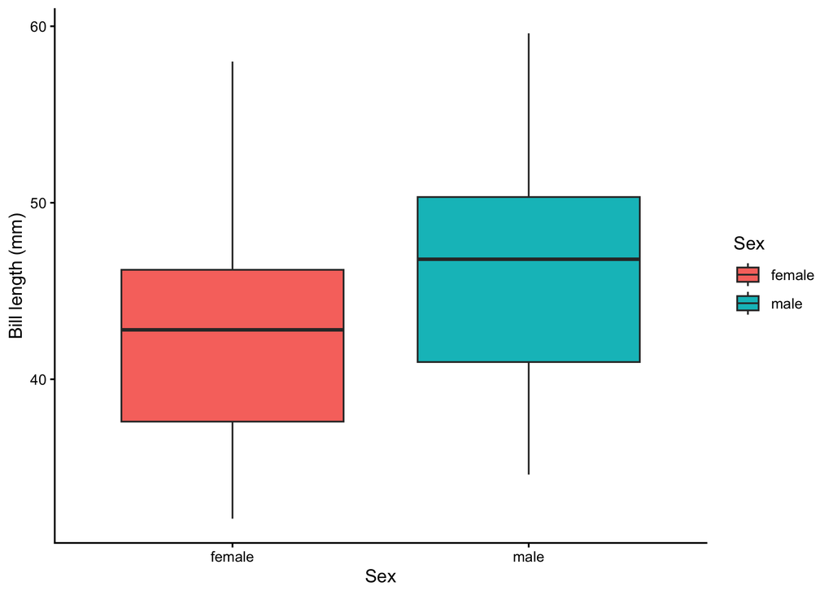

#### 7. Adapt the code from task 6 to show three species boxplots side by side within each sex group.

- *Tip:* reuse the code above and change `fill` inside `aes(...)`

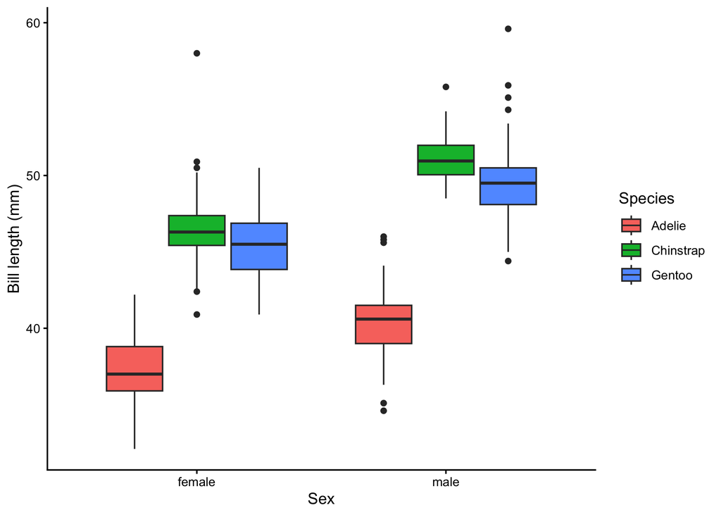

#### 8. Create a scatter plot to show the relationship between `bill_length_mm` and `bill_depth_mm`.

- Make dots colored filled with `'blue'`
- **This task can be solved using either basic R or `ggplot`**

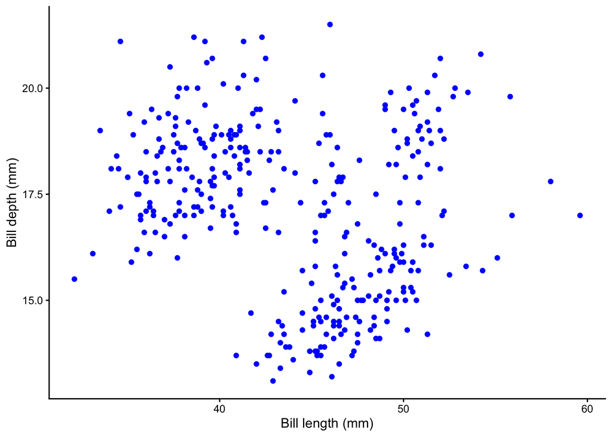

#### 9. Create a Bubble plot: a scatter plot depicting the relationships between `bill_length_mm` and `bill_depth_mm`, with colored dots representing `species` and sizes reflecting `flipper_length_mm`.

- Points should have `alpha=0.7`

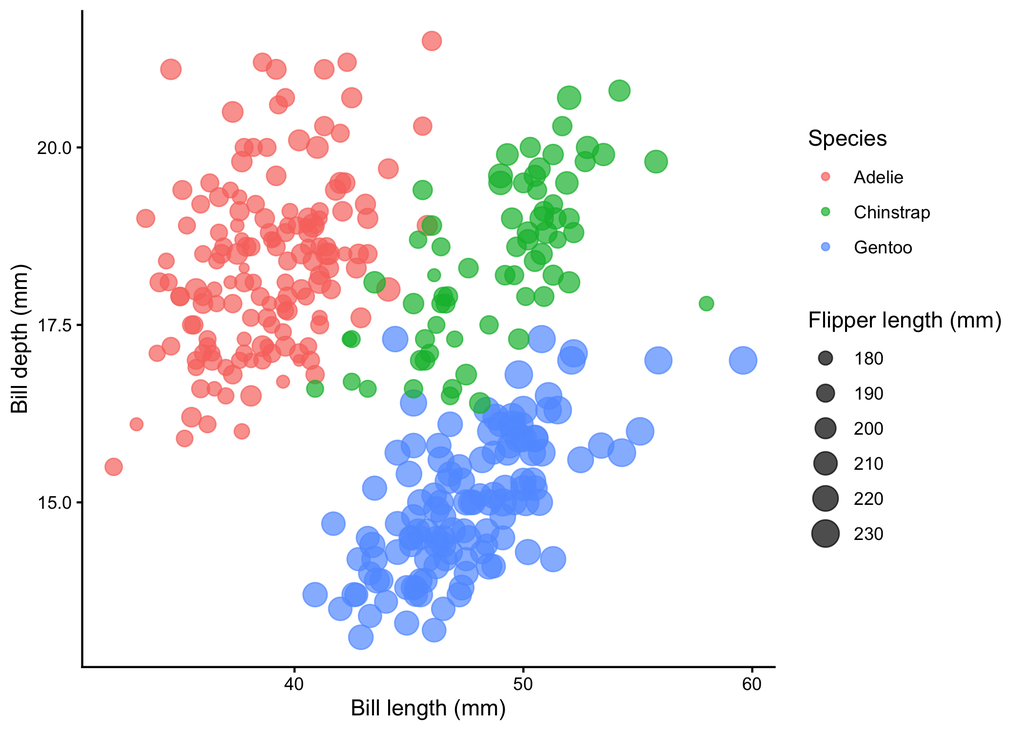

#### 10. Split the bubble plot from task 9 into separate panels for each `species`.

- *Tip:* remember `facet_wrap()`
- To do that you should save plot above as variable and add (`+`) facets
- Don’t forget to show the plot!

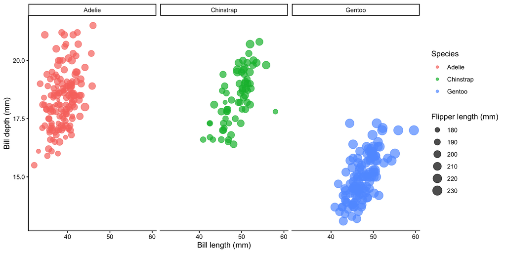

#### 11.* Arrange any two plots created above next to each other

- use `patchwork` library

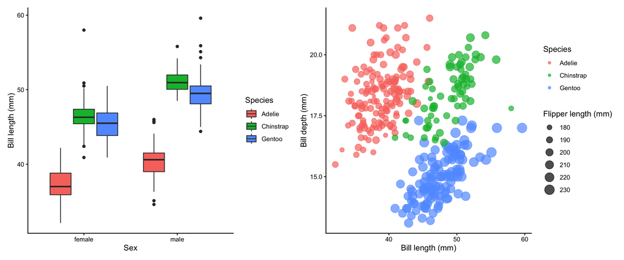